### Classifying Users on GitHub

#### Historical Overview (September 2019-October 2021)

#### Brandon L. Kramer (UVA Biocomplexity)

Over the past two years, the UVA NCSES OSS team has been developing methods to classify GitHub users into organizations, sectors, and geographies. The geographic classification progress spans from September 2019-Present while the sectoring classification ranges from Summer 2020-Present. This document provides an overview of the progress made as well as a number of pertinent links for understanding the development of this projet.

### GitHub User Data

| dataset | date_scraped | n_users | w_company_data | w_email_data | w_location_data |
| --- | --- | --- | --- | --- | --- |
| GHTorrent | 2019-06-30 | 2,143,632 | 422,517 (19.7%) | 579,077 (27.0%) | 735,441 (34.3%) |
| SDAD Scrape + GHTorrent | 2021-08-28 | 3,212,546 | 764,781 (23.8%) | 831,021 (25.9%) | 1,260,266 (39.2%) |

As we have documented elsewhere, we collected all GitHub user activity in repositories that (1) have OSI-approved licenses, (2) were created between 2008-2019, and (3) had original content (not forked, not mirrored, and not archived) using the GHOST.jl package. Once the user activity data was collected, we procured user data from [GHTorrent](https://ghtorrent.org/), which was scraped sometime during June 2019, and then joined those users back to all users that were in our user activity dataset. We did not update this user data until August 2021 when we developed a [Python script](https://github.com/uva-bi-sdad/oss-2020/blob/master/src/10_users_update/01_scrape_user_data.ipynb) to obtain all user-level data. Above, we have summarized the totals for each dataset, showing that the August 2021 scrape provides a much larger dataset that has roughly the same percentage coverage in the three main columns used to classify users. For those looking to use these tables internally, the GHTorrent data is named `gh.ctrs_extra` and the August 2021 data is named `gh.ctrs_clean_0821` on the database.

### Initial Approaches to Classifying GitHub Users

The initial classification processes were developed over the two-year period from 2019-2021. In Fall 2019, our team [developed an approach that used string matching with regular expressions](https://github.com/uva-bi-sdad/oss-2020/blob/master/src/05_github-networks/02_international-networks/01_network-construction/01_github-to-ctry-code.Rmd) to probabalistically match users self-reported user information into country codes. This approach was developed a bit further in Fall 2020 when we [published a pipeline to evalutate international collaborations in OSS](https://github.com/uva-bi-sdad/oss-2020/blob/master/src/07_ncses-indicators/02_intl_collaborations/02_github-users-to-ctry.Rmd) for the NCSES. In theory, this approach should work fine, but using regex requires a lot of time to match precise strings. Moreover, it requires regex strings to remove punctuation and other forms of variation in text.

One alternative to using a regex approach is probabalistic record linkage. During the [2020 UVA DSPG OSS Summer Project](https://dspg-young-scholars-program.github.io/dspg20oss/?dspg), we used this strategy to match users to academic, business, government, and non-profit agencies and finalized this during [Fall 2020](https://github.com/uva-bi-sdad/oss-2020/blob/master/src/03_github-sectoring/02_sna_ctr_sectors.Rmd). Though this works pretty well overall, the main problem is that small variations in text ultimately lead to joins not coming together. While our team was working on a classification approach for software types in our [UVA DSPG OSS 2021 Summer Project](https://dspgtools.shinyapps.io/dspg21oss/), we conceptualized another possibility for matching users - one we call a “funnel matching” approach. This strategy basically uses the `R`’s `tidytext` package to unnest sequences of words in text and then match them to a curated dictionary of terms. Doing so, allows strings like “university of california berkeley” and “cal berkeley” to both match to a prepared dictionary and then be standardized to one common outcome for accurate counts.

### Improvements Made Using Packages

| dataset | dev_date | n_users | w_any_data | in_country | in_academia | time_to_run |
| --- | --- | --- | --- | --- | --- | --- |
| Previous Approaches | 2021-01-20 | 2,143,632 | 1,019,189 (47.6%) | 732,636 (71.8%/87.1%)* | 51,343 (6.42%/14.3%)** | NA |
| Packages | 2021-10-13 | 3,212,546 | 1,576,284 (49.0%) | 1,235,107 (78.4%/89.1%)* | 109,311 (9.0%/19.2%)** | 39.2 mins |

(*) The geographic percentages were originally calculated with denominators that included any text data in the location, email or company columns. However, not all text data is valid so the second percentage includes a more realistic estimate that removes non-classificable email domains (e.g., gmail.com) and geographic information (e.g. earth).

(**) Academic percentages were originally calculated using any data in email or company columns as the denominator.

### Geographic Classification

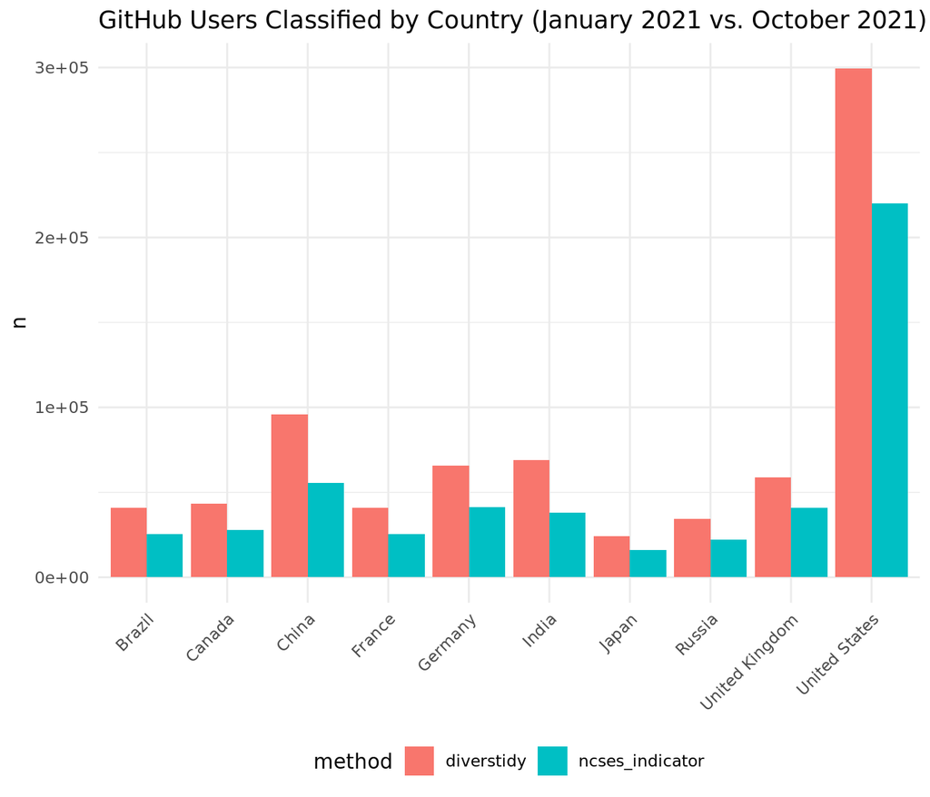

| country | diverstidy | ncses_indicator | prc_increase | relative_change |
| --- | --- | --- | --- | --- |
| United States | 299460 | 220239 | 35.97 | -19.35 |
| China | 96005 | 55370 | 73.39 | 2.85 |
| Germany | 65851 | 41148 | 60.03 | -5.07 |
| United Kingdom | 58822 | 40718 | 44.46 | -14.31 |
| India | 69138 | 38091 | 81.51 | 7.67 |
| Canada | 43263 | 27977 | 54.64 | -8.27 |
| Brazil | 41024 | 25586 | 60.34 | -4.89 |
| France | 41007 | 25548 | 60.51 | -4.79 |
| Russia | 34385 | 22197 | 54.91 | -8.11 |
| Japan | 24165 | 16258 | 48.63 | -11.83 |

[output cut: 263 more lines]

### Academic Classification

```
## [1] TRUE
```

| organization | n |
| --- | --- |
| university of california, berkeley | 1889 |
| misc. student | 1546 |
| massachusetts institute of technology | 933 |
| stanford university | 818 |
| carnegie mellon university | 813 |
| university of washington | 730 |
| university of southern california | 703 |
| cornell university | 694 |
| new york university | 624 |
| university of michigan - ann arbor | 616 |

[output cut: 5143 more lines]

| organization | n |
| --- | --- |
| Misc. Academic | 12841 |
| University of California-Berkeley | 1718 |
| Massachusetts Institute of Technology | 1472 |
| Carnegie Mellon University | 1367 |
| Stanford University | 1319 |
| University of Washington-Seattle Campus | 1198 |
| University of Southern California | 1132 |
| New York University | 1071 |
| University of Michigan-Ann Arbor | 1022 |
| Indian Institute of Technology Delhi | 953 |

[output cut: 3499 more lines]

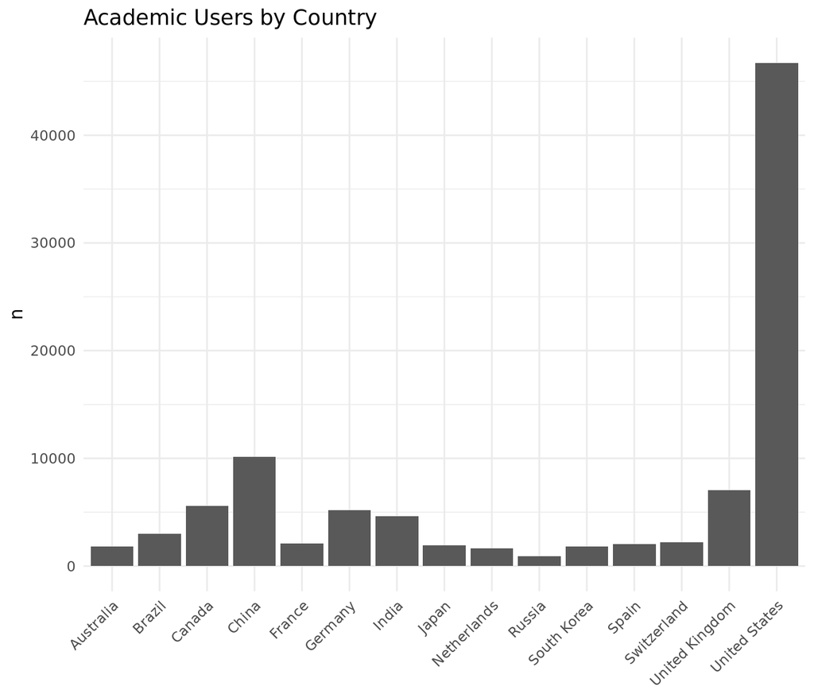

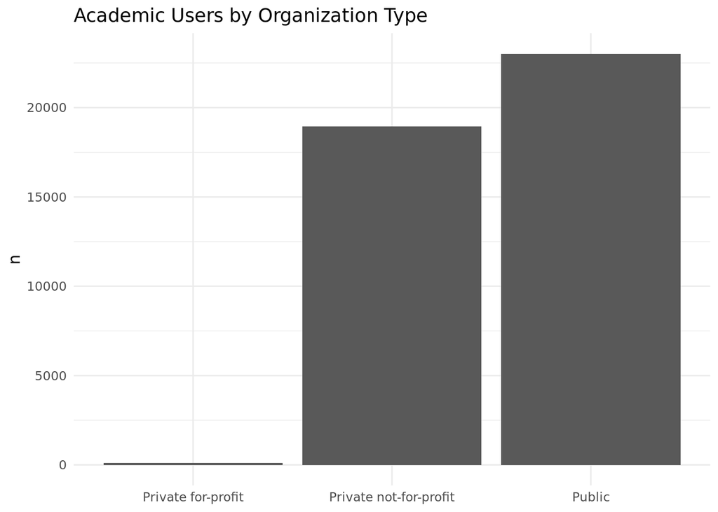

### Additional Updates (October 14, 2021)

- Added additional output parameters in `detect_orgs()` (“country”, “parent_org”, and “org_type”)
- Added additional output parameters in `detect_geographies()` (“country”, “iso_2”, “iso_3”, “flag”, “continent”, “region”, “sub_region”, “int_region”, “country_chinese”, “country_russian”, “country_french”, “country_spanish”, “country_arabic”) along with booleans and warnings for email, cities and denonyms
- Next steps are to use the preliminary results to calculate personal months to hand off to JSBC and CR
- After this, Brandon is going to integrate small sample examples for business, government, and nonprofit sectors to be sure the approach scales
- Then Brandon will work through debranching and ranking system

### Non-Profit Classification

#### Important Links

[2020 UVA DSPG Project Website](https://dspg-young-scholars-program.github.io/dspg20oss/?dspg)

[2021 UVA DSPG Project Website](https://dspgtools.shinyapps.io/dspg21oss/)

[tidysocial Documentation](https://github.com/brandonleekramer/tidysocial-bookdown)

[`diverstidy` Package](https://github.com/brandonleekramer/diverstidy)

[`tidyorgs` Package](https://github.com/brandonleekramer/tidyorgs/)

[GHOST.jl Software Package](https://github.com/uva-bi-sdad/GHOST.jl)

[Scraping Script for GitHub Users in Python](https://github.com/uva-bi-sdad/oss-2020/blob/master/src/10_users_update/01_scrape_user_data.ipynb)